# Loan Approval

## Home Loan Approval

Home loan approval dataset from: https://www.kaggle.com/datasets/rohit265/loan-approval-dataset/data

## About

This dataset offers valuable insights into the characteristics and risk assessments of loan applicants. It contains detailed information on various attributes such as demographic, financial, employment, and home ownership status. With a mix of numerical and categorical features, this dataset is well-suited for a range of analytical methods!

This dataset reflects regions in India!

I chose this dataset because I am very interested in the housing market, and while the sudden increase in housing value is a hot topic, I wanted to analyze the topic from a different angle.

## Hypothesis

I believe "profession" will have the highest impact on risk assessment with artist and comedian being the highest risk careers.

## Columns

**Id**: Unique identifier for each loan applicant.  
**Income**: The income level of the applicant.  
**Age**: Age of the applicant.  
**Experience**: Years of professional experience.  
**Married/Single**: Marital status of the applicant.  
**House_Ownership**: Indicates whether the applicant owns or rents a house.  
**Car_Ownership**: Indicates whether the applicant owns a car.  
**Profession**: Occupation or profession of the applicant.  
**CITY**: City of residence of the applicant.  
**STATE**: State of residence of the applicant.  
**CURRENT_JOB_YRS**: Duration of employment in the current job.  
**CURRENT_HOUSE_YRS**: Duration of residence in the current house.  
**Risk_Flag**: Binary indicator of loan risk, where 1 represents a flagged risky applicant and 0 represents a non-risky applicant.

```python
import pandas as pd
import matplotlib.pyplot as plt
import seaborn as sns
import numpy as np
from sklearn.preprocessing import LabelEncoder
from sklearn.ensemble import RandomForestClassifier
from sklearn.metrics import accuracy_score
from sklearn.model_selection import train_test_split
from sklearn import metrics

import warnings
warnings.filterwarnings("ignore")
```

## What does the data look like out of the box?

```python
df=pd.read_json('data/loan_approval_dataset.json')
df
```

|  | Id | Income | Age | Experience | Married/Single | House_Ownership | Car_Ownership | Profession | CITY | STATE | CURRENT_JOB_YRS | CURRENT_HOUSE_YRS | Risk_Flag |
| --- | --- | --- | --- | --- | --- | --- | --- | --- | --- | --- | --- | --- | --- |
| 0 | 1 | 1303834 | 23 | 3 | single | rented | no | Mechanical_engineer | Rewa | Madhya_Pradesh | 3 | 13 | 0 |
| 1 | 2 | 7574516 | 40 | 10 | single | rented | no | Software_Developer | Parbhani | Maharashtra | 9 | 13 | 0 |
| 2 | 3 | 3991815 | 66 | 4 | married | rented | no | Technical_writer | Alappuzha | Kerala | 4 | 10 | 0 |
| 3 | 4 | 6256451 | 41 | 2 | single | rented | yes | Software_Developer | Bhubaneswar | Odisha | 2 | 12 | 1 |
| 4 | 5 | 5768871 | 47 | 11 | single | rented | no | Civil_servant | Tiruchirappalli[10] | Tamil_Nadu | 3 | 14 | 1 |
| ... | ... | ... | ... | ... | ... | ... | ... | ... | ... | ... | ... | ... | ... |
| 251995 | 251996 | 8154883 | 43 | 13 | single | rented | no | Surgeon | Kolkata | West_Bengal | 6 | 11 | 0 |
| 251996 | 251997 | 2843572 | 26 | 10 | single | rented | no | Army_officer | Rewa | Madhya_Pradesh | 6 | 11 | 0 |
| 251997 | 251998 | 4522448 | 46 | 7 | single | rented | no | Design_Engineer | Kalyan-Dombivli | Maharashtra | 7 | 12 | 0 |
| 251998 | 251999 | 6507128 | 45 | 0 | single | rented | no | Graphic_Designer | Pondicherry | Puducherry | 0 | 10 | 0 |
| 251999 | 252000 | 9070230 | 70 | 17 | single | rented | no | Statistician | Avadi | Tamil_Nadu | 7 | 11 | 0 |

252000 rows × 13 columns

```python
df.describe(include='all').T
```

|  | count | unique | top | freq | mean | std | min | 25% | 50% | 75% | max |
| --- | --- | --- | --- | --- | --- | --- | --- | --- | --- | --- | --- |
| Id | 252000.0 | NaN | NaN | NaN | 126000.5 | 72746.278255 | 1.0 | 63000.75 | 126000.5 | 189000.25 | 252000.0 |
| Income | 252000.0 | NaN | NaN | NaN | 4997116.665325 | 2878311.013611 | 10310.0 | 2503015.0 | 5000694.5 | 7477502.0 | 9999938.0 |
| Age | 252000.0 | NaN | NaN | NaN | 49.954071 | 17.063855 | 21.0 | 35.0 | 50.0 | 65.0 | 79.0 |
| Experience | 252000.0 | NaN | NaN | NaN | 10.084437 | 6.00259 | 0.0 | 5.0 | 10.0 | 15.0 | 20.0 |
| Married/Single | 252000 | 2 | single | 226272 | NaN | NaN | NaN | NaN | NaN | NaN | NaN |
| House_Ownership | 252000 | 3 | rented | 231898 | NaN | NaN | NaN | NaN | NaN | NaN | NaN |
| Car_Ownership | 252000 | 2 | no | 176000 | NaN | NaN | NaN | NaN | NaN | NaN | NaN |
| Profession | 252000 | 51 | Physician | 5957 | NaN | NaN | NaN | NaN | NaN | NaN | NaN |
| CITY | 252000 | 317 | Vijayanagaram | 1259 | NaN | NaN | NaN | NaN | NaN | NaN | NaN |
| STATE | 252000 | 29 | Uttar_Pradesh | 28400 | NaN | NaN | NaN | NaN | NaN | NaN | NaN |
| CURRENT_JOB_YRS | 252000.0 | NaN | NaN | NaN | 6.333877 | 3.647053 | 0.0 | 3.0 | 6.0 | 9.0 | 14.0 |
| CURRENT_HOUSE_YRS | 252000.0 | NaN | NaN | NaN | 11.997794 | 1.399037 | 10.0 | 11.0 | 12.0 | 13.0 | 14.0 |
| Risk_Flag | 252000.0 | NaN | NaN | NaN | 0.123 | 0.328438 | 0.0 | 0.0 | 0.0 | 0.0 | 1.0 |

```python
print(df.dtypes)
```

```
Id                    int64
Income                int64
Age                   int64
Experience            int64
Married/Single       object
House_Ownership      object
Car_Ownership        object
Profession           object
CITY                 object
STATE                object
CURRENT_JOB_YRS       int64
CURRENT_HOUSE_YRS     int64
Risk_Flag             int64
dtype: object
```

## Cleaning the data

There isn't much cleaning necessary for my purposes with this data set, however some data types don't need to be an object. It would make the most sense to have Married/single and Car_Ownership as boolean, but I may want to know the mean of these columns, and Pandas doesn't like finding the mean of boolean values.

```python
df['Married/Single'] = df['Married/Single'].map({'Single': 0, 'Married': 1})
df['Married/Single'] = df['Married/Single'].fillna(0).astype('int64')
df['Car_Ownership'] = df['Car_Ownership'].map({'no': 0, 'yes': 1}).astype('int64')
print(df.dtypes)
```

```
Id                    int64
Income                int64
Age                   int64
Experience            int64
Married/Single        int64
House_Ownership      object
Car_Ownership         int64
Profession           object
CITY                 object
STATE                object
CURRENT_JOB_YRS       int64
CURRENT_HOUSE_YRS     int64
Risk_Flag             int64
dtype: object
```

## Graph Time

Taking a closer look at Profession, I want to show the mean Risk_Flag for each Profession.

[figure not shown]

```python
# Calculate the ratio of Risk_Flag for each profession
profession_risk_ratio = df.groupby('Profession')['Risk_Flag'].mean()

# Sort the values for better visualization
profession_risk_ratio = profession_risk_ratio.sort_values()

# Define colors. Highlighting Artist and Comedian so show my hypothesis
colors = ['grey' if profession not in ['Artist', 'Comedian'] else 'red' for profession in profession_risk_ratio.index]

plt.figure(figsize=(10, 20))
ax = sns.barplot(x=profession_risk_ratio.values, y=profession_risk_ratio.index, palette=colors)

plt.title("Ratio of Risk by Profession")
plt.xlabel("Ratio of Risk_Flag (1)")
plt.ylabel("Profession")

# Add bar labels
for container in ax.containers:
    ax.bar_label(container, fmt='%.2f')

plt.show()
```

## Observation

I was not expecting Comedian and Artist to be so close to the median. I find it interesting that Web Designer is low risk on this graph and Software Developer is high risk.

## Feature Importance Analysis

In this section, we analyze the importance of various features in predicting loan risk using a Random Forest classifier.

```python
# Convert categorical columns to numeric using one-hot encoding
fi = pd.get_dummies(df, columns=['Married/Single', 'House_Ownership', 'Car_Ownership', 'Profession'], drop_first=True)

# Select the specified columns and target variable
columns = ['Income', 'Age', 'Experience', 'CURRENT_JOB_YRS', 'CURRENT_HOUSE_YRS'] + [col for col in fi.columns if col.startswith('Married/Single_') or col.startswith('House_Ownership_') or col.startswith('Car_Ownership_') or col.startswith('Profession_')]
X = fi[columns]
y = fi['Risk_Flag']

# Drop the 'Id' column because it shows up on the graph and is irrelevant
fi = fi.drop(columns=['Id'])

# Split the data into training and testing sets
X_train, X_test, y_train, y_test = train_test_split(X, y, test_size=0.2, random_state=42)

# Train a Random Forest model
model = RandomForestClassifier(random_state=42)
model.fit(X_train, y_train)

# Get feature importances
feature_importances = model.feature_importances_
feature_names = X.columns

# Create a DataFrame for visualization
feature_importances_fi = pd.DataFrame({
    'Feature': feature_names,
    'Importance': feature_importances
})

# Sort the DataFrame by importance
feature_importances_fi = feature_importances_fi.sort_values(by='Importance', ascending=False)

# Define colors for the barplot
colors = ['black' if 'Profession_' in feature else None for feature in feature_importances_fi['Feature']]
unique_colors = sns.color_palette("husl", len([c for c in colors if c is None]))

# Assign unique colors to non-Profession features
color_idx = 0
for i in range(len(colors)):
    if colors[i] is None:
        colors[i] = unique_colors[color_idx]
        color_idx += 1
```

## Graph Interpretation

The bar plot displays the importance of each feature in determining loan risk. Features related to the applicant's Profession are highlighted in black, while other features have distinct colors. This distinction helps in visually separating the impact of profession-related features from others.

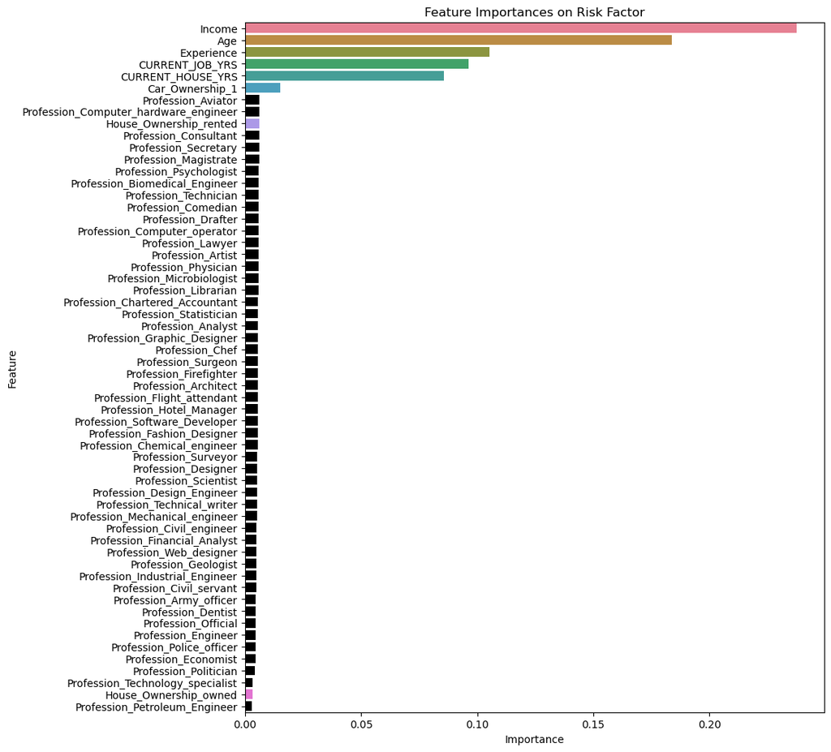

```python
# Plot the feature importances
plt.figure(figsize=(10, 12))
sns.barplot(x='Importance', y='Feature', data=feature_importances_fi, palette=colors)
plt.title('Feature Importances on Risk Factor')
plt.xlabel('Importance')
plt.ylabel('Feature')
plt.show()
```

## Observation

Income is the most important feature for Risk Factor (this make sense), but this graph isn't a fair representation of Profession's impact on Risk Factor.

## Diving into Average Income by Profession

We need to take a look at the average income for each profession to see if a correlation exists. In other words: does the profession supply the high income, which results in low Risk Factor, or is the profession irrelevant to income?

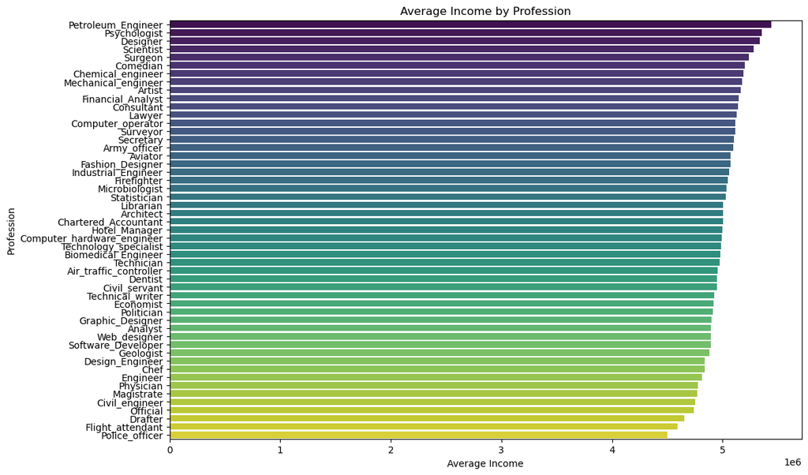

```python
# Group by profession and calculate the average income
average_income_by_profession = df.groupby('Profession')['Income'].mean().reset_index()

# Sort the professions by average income
average_income_by_profession = average_income_by_profession.sort_values(by='Income', ascending=False)

# Plot the average income for each profession
plt.figure(figsize=(12, 8))
sns.barplot(x='Income', y='Profession', data=average_income_by_profession, palette='viridis')
plt.title('Average Income by Profession')
plt.xlabel('Average Income')
plt.ylabel('Profession')
plt.show()
```

## Observation

At first glace, some of these Professions' incomes match the risk factor graph at the start (police officer is high risk and petroleum engineer is low risk, however some Professions' incomes don't match (artist and comedian have high income, but they were in the median range for Risk Factor.

We need a better visualisation of this data!

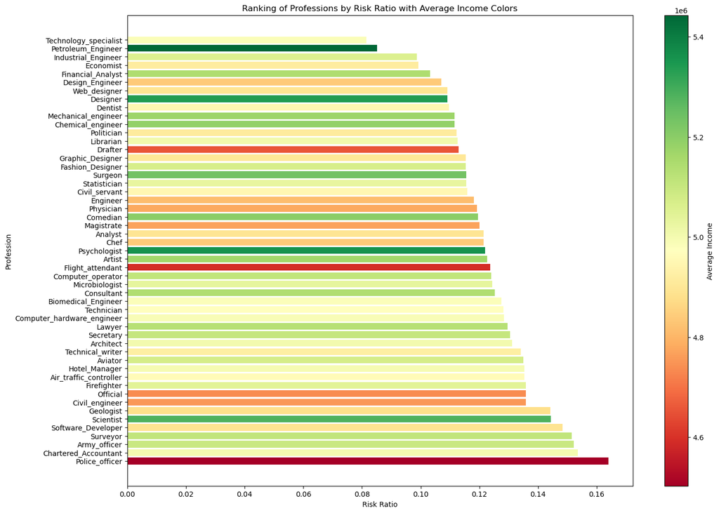

```python
# Calculate average income for each profession
average_income_by_profession = df.groupby('Profession')['Income'].mean().reset_index()

# Calculate the ratio of risk for each profession
risk_ratio_by_profession = df.groupby('Profession')['Risk_Flag'].mean().reset_index()
risk_ratio_by_profession.rename(columns={'Risk_Flag': 'Risk_Ratio'}, inplace=True)

# Merge the two datasets on the profession column
profession_stats = pd.merge(average_income_by_profession, risk_ratio_by_profession, on='Profession')

# Sort the professions by Risk_Ratio in ascending order (low risk at top, high risk at bottom)
profession_stats = profession_stats.sort_values(by='Risk_Ratio')

# Normalize the income values for coloring
norm = plt.Normalize(profession_stats['Income'].min(), profession_stats['Income'].max())
colors = plt.cm.RdYlGn(norm(profession_stats['Income']))

# Plotting
plt.figure(figsize=(16, 12))
bars = plt.barh(profession_stats['Profession'], profession_stats['Risk_Ratio'], color=colors)
plt.gca().invert_yaxis()  # Invert y-axis to have low risk at the top
plt.xlabel('Risk Ratio')
plt.ylabel('Profession')
plt.title('Ranking of Professions by Risk Ratio with Average Income Colors')

# Add a color bar
sm = plt.cm.ScalarMappable(cmap='RdYlGn', norm=norm)
sm.set_array(profession_stats['Income'])  # Set the array to the income values for the color bar
cbar = plt.colorbar(sm, ax=plt.gca())  # Specify the current axes
cbar.set_label('Average Income')

plt.show()
```

## Graph Interpretation

This graph is the same as the "Ratio of Risk for each Profession", however each profession is colored to represent their average income. If my hypothesis was correct, the graph should match the color legend on the right.

## Conclusion

This was an interesting dataset to work with, and I found it enlightening to see that I was completely wrong in my hypothesis in that profession has little to do with risk of home loan approval (with exceptions, I feel bad for police officers in India).